# R Notebook

Parkinson’s disease (PD) is a neurodegenerative disorder that affects predominately dopamine-producing neurons in a specific area of the brain called substantia nigra.

Symptoms generally develop slowly over years. The progression of symptoms is often a bit different from one person to another due to the diversity of the disease. People with PD may experience:

Tremor, mainly at rest and described as pill rolling tremor in hands. Other forms of tremor are possible Slowness of movements (bradykinesia) Limb rigidity Gait and balance problems Let’s come to the dataset. This dataset is from UCI Machine Learning Repository.This dataset is composed of a range of biomedical voice measurements from 31 people, 23 with Parkinson’s disease (PD). Each column in the table is a particular voice measure, and each row corresponds one of 195 voice recording from these individuals (“name” column). The main aim of the data is to discriminate healthy people from those with PD, according to “status” column which is set to 0 for healthy and 1 for PD.

Our problem is to predict any individual as healthy or not. Parkinson’s disease (PD) is a neurodegenerative disorder that affects predominately dopamine-producing neurons in a specific area of the brain called substantia nigra.

Symptoms generally develop slowly over years. The progression of symptoms is often a bit different from one person to another due to the diversity of the disease. People with PD may experience:

Tremor, mainly at rest and described as pill rolling tremor in hands. Other forms of tremor are possible Slowness of movements (bradykinesia) Limb rigidity Gait and balance problems Let’s come to the dataset. This dataset is from UCI Machine Learning Repository.This dataset is composed of a range of biomedical voice measurements from 31 people, 23 with Parkinson’s disease (PD). Each column in the table is a particular voice measure, and each row corresponds one of 195 voice recording from these individuals (“name” column). The main aim of the data is to discriminate healthy people from those with PD, according to “status” column which is set to 0 for healthy and 1 for PD. We will be using Logistic Regression.

Our problem is to predict any individual as healthy or not.

```r
data <- read.csv(file = 'parkinsons.data')
```

We have our data set called “data”. Let’s get a view and summary of the dataset.

```r
head(data,6)
```

|  | name | MDVP.Fo.Hz. | MDVP.Fhi.Hz. | MDVP.Flo.Hz. | MDVP.Jitter... | MDVP.Jitter.Abs. | MDVP.RAP | MDVP.PPQ | Jitter.DDP | MDVP.Shimmer | MDVP.Shimmer.dB. | Shimmer.APQ3 | Shimmer.APQ5 | MDVP.APQ | Shimmer.DDA | NHR | HNR | status | RPDE | DFA | spread1 | spread2 | D2 | PPE |
| --- | --- | --- | --- | --- | --- | --- | --- | --- | --- | --- | --- | --- | --- | --- | --- | --- | --- | --- | --- | --- | --- | --- | --- | --- |
| 1 | phon_R01_S01_1 | 119.992 | 157.302 | 74.997 | 0.00784 | 0.00007 | 0.00370 | 0.00554 | 0.01109 | 0.04374 | 0.426 | 0.02182 | 0.03130 | 0.02971 | 0.06545 | 0.02211 | 21.033 | 1 | 0.414783 | 0.815285 | -4.813031 | 0.266482 | 2.301442 | 0.284654 |
| 2 | phon_R01_S01_2 | 122.400 | 148.650 | 113.819 | 0.00968 | 0.00008 | 0.00465 | 0.00696 | 0.01394 | 0.06134 | 0.626 | 0.03134 | 0.04518 | 0.04368 | 0.09403 | 0.01929 | 19.085 | 1 | 0.458359 | 0.819521 | -4.075192 | 0.335590 | 2.486855 | 0.368674 |
| 3 | phon_R01_S01_3 | 116.682 | 131.111 | 111.555 | 0.01050 | 0.00009 | 0.00544 | 0.00781 | 0.01633 | 0.05233 | 0.482 | 0.02757 | 0.03858 | 0.03590 | 0.08270 | 0.01309 | 20.651 | 1 | 0.429895 | 0.825288 | -4.443179 | 0.311173 | 2.342259 | 0.332634 |
| 4 | phon_R01_S01_4 | 116.676 | 137.871 | 111.366 | 0.00997 | 0.00009 | 0.00502 | 0.00698 | 0.01505 | 0.05492 | 0.517 | 0.02924 | 0.04005 | 0.03772 | 0.08771 | 0.01353 | 20.644 | 1 | 0.434969 | 0.819235 | -4.117501 | 0.334147 | 2.405554 | 0.368975 |
| 5 | phon_R01_S01_5 | 116.014 | 141.781 | 110.655 | 0.01284 | 0.00011 | 0.00655 | 0.00908 | 0.01966 | 0.06425 | 0.584 | 0.03490 | 0.04825 | 0.04465 | 0.10470 | 0.01767 | 19.649 | 1 | 0.417356 | 0.823484 | -3.747787 | 0.234513 | 2.332180 | 0.410335 |
| 6 | phon_R01_S01_6 | 120.552 | 131.162 | 113.787 | 0.00968 | 0.00008 | 0.00463 | 0.00750 | 0.01388 | 0.04701 | 0.456 | 0.02328 | 0.03526 | 0.03243 | 0.06985 | 0.01222 | 21.378 | 1 | 0.415564 | 0.825069 | -4.242867 | 0.299111 | 2.187560 | 0.357775 |

```r
dim(data)
```

```
[1] 195  24
```

```r
na = colSums(is.na(data))
```

no missing values.

So “status” is our variable of interest. We would like to predict the class of the ‘status’ of any individuals. It’s a classification problem. We are going to use various classification algorithm for this problem. # Feature scaling

```r
data[,-  c(1,18)] <- scale(data[,-c(1,18)])
```

#define the columns that contain your abundance data. Change the number after the “:” to subset your data

```r
com = data[,2:23]
```

Now create a correlation matrix with your community composition data using the command ‘cor’

```r
cc = cor(com, method = "spearman")
```

Now you have a correlation matrix that contains correlation coefficients for every pairwise combination of variables in our data and Spearman captures all types of positive or negative relationships Spearman correlation: is a non-parametric measure of rank correlation and assesses how well a relationship between two variables can be described using a monotonic function. The easiest way to visualize this correlation matrix is using the function “ggcorrplot” from the package ggcorrplot

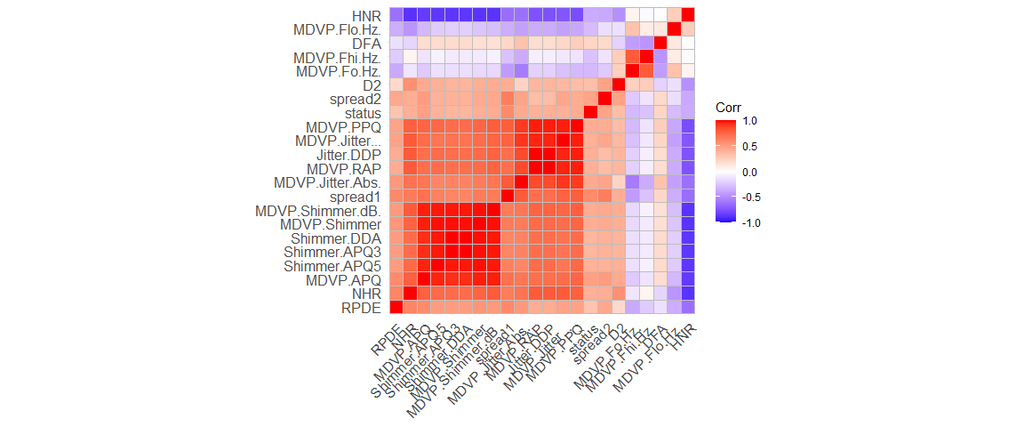

```r
library(ggcorrplot)

ggcorrplot(cc,hc.order="TRUE")
```

It is clear that correlated features means that they bring the same information, so it is logical to remove one of them. When we have highly correlated features, the variance will be large.

Removing the highly correlated variables

```r
  data <- subset(data, select = -c(1,5,6,8,10,11,12,14))
```

Now we have removed the highly correlated variables from the dataset.

let’s have a basic idea of each variable respect to the ‘status’ variable. We are going to plot various box-plots for each variable.

```r
attach(data)
data.m =melt(data[,-1],id.vars = "status")
d <- ggplot(data = data.m, aes(x=variable, y=value)) +
             geom_boxplot(aes(fill=status))
d + facet_wrap( ~ variable, scales="free")
```

[output not shown]

```r
outlier_remove=function(x){
    quantiles <- quantile( x, c(.25, .75 ) )
    iqr=IQR(x)
    med=median(x)
    x[ x < quantiles[1]-iqr ] <- med
    x[ x > quantiles[2]+ iqr] <- med
    x
}
```

replacing the outliers

```r
data$MDVP.RAP= outlier_remove(data$MDVP.RAP)
data$Jitter.DDP= outlier_remove(data$Jitter.DDP)
data$NHR= outlier_remove(data$NHR)
```

now we age going to split our data into training and test data

```r
library(caTools)
split=sample.split(data$status,SplitRatio = .80)
train=subset(data,split==T)
test=subset(data,split==F)
```

Model fitting

```r
library(caret)
model.lg= glm(data=train,status~.,family = "binomial")
summary(model.lg)
step(model.lg,direction="backward")
```

[output not shown]

The Akaike information criterion (AIC) is an estimator of out-of-sample prediction error and thereby relative quality of statistical models for a given set of data.Lower AIC values indicate a better-fit model

We will select the model with lowest AIC that is status ~ NHR + RPDE + spread1 + spread2

```r
final.model= glm(formula = status ~ NHR + RPDE + spread1 + spread2, family = "binomial",
    data = train)
summary(final.model)
```

```
Call:
glm(formula = status ~ NHR + RPDE + spread1 + spread2, family = "binomial",
    data = train)

Deviance Residuals:
     Min        1Q    Median        3Q
-2.58160   0.00415   0.11918   0.47400
     Max
 1.80848

Coefficients:
            Estimate Std. Error z value
(Intercept)   4.1496     0.9270   4.476
NHR           4.7611     2.2325   2.133
RPDE         -1.0650     0.3810  -2.795
spread1       2.6191     0.6298   4.159
spread2       0.9017     0.3925   2.298
            Pr(>|z|)
(Intercept) 7.59e-06 ***
NHR          0.03295 *
RPDE         0.00519 **
spread1     3.20e-05 ***
spread2      0.02159 *
---
Signif. codes:
0 ‘***’ 0.001 ‘**’ 0.01 ‘*’ 0.05 ‘.’ 0.1 ‘ ’ 1

(Dispersion parameter for binomial family taken to be 1)

    Null deviance: 173.217  on 155  degrees of freedom
Residual deviance:  89.378  on 151  degrees of freedom
AIC: 99.378

Number of Fisher Scoring iterations: 7
```

We will check our model’s accuracy now. First we will use our training data.

Fitting the model

```r
train$pred<-fitted(final.model)
```

Predicting the train dataset

```r
pred <-prediction(train$pred,train$status)
```

Create Performance Objects and plotting graph

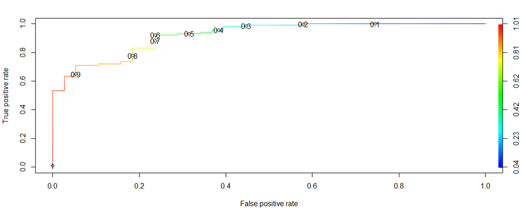

```r
perf<-performance(pred,"tpr","fpr")
plot(perf,colorize = T,print.cutoffs.at = seq(0.1,by = 0.1))
```

```r
pre <- as.numeric(predict(final.model,type="response")>0.9)
```

creating the confusion matrix

```r
confusionMatrix(table(pre,train$status))
```

```
Confusion Matrix and Statistics


pre  0  1
  0 36 42
  1  2 76

               Accuracy : 0.7179
                 95% CI : (0.6404, 0.787)
    No Information Rate : 0.7564
    P-Value [Acc > NIR] : 0.8861

                  Kappa : 0.4359

 Mcnemar's Test P-Value : 4.116e-09

            Sensitivity : 0.9474
            Specificity : 0.6441
         Pos Pred Value : 0.4615
         Neg Pred Value : 0.9744
             Prevalence : 0.2436
         Detection Rate : 0.2308
   Detection Prevalence : 0.5000
      Balanced Accuracy : 0.7957

       'Positive' Class : 0
```

Now validating the model on testing data

```r
pre  <- as.numeric(predict(final.model,newdata=test,type="response")>0.9)
```

# type = “response” is used to get the outcome in the form of probability of having parkinson’s disease. As we know that, for training data the cutoff has been 0.9.Similarly the testing data will also have the same threshold or cutoff.

making the confusion matrix

```r
confusionMatrix(table(pre,test$status))
```

```
Confusion Matrix and Statistics


pre  0  1
  0  8  6
  1  2 23

               Accuracy : 0.7949
                 95% CI : (0.6354, 0.907)
    No Information Rate : 0.7436
    P-Value [Acc > NIR] : 0.2988

                  Kappa : 0.5244

 Mcnemar's Test P-Value : 0.2888

            Sensitivity : 0.8000
            Specificity : 0.7931
         Pos Pred Value : 0.5714
         Neg Pred Value : 0.9200
             Prevalence : 0.2564
         Detection Rate : 0.2051
   Detection Prevalence : 0.3590
      Balanced Accuracy : 0.7966

       'Positive' Class : 0
```

Balanced Accuracy of Testing data is 79.66%

To check how much of our predicted values lie inside the curve

```r
auc<-performance(pred,"auc")
auc@y.values
```

```
[[1]]
[1] 0.9201606
```